# EasyVisa Project

Hyperparameter Tuning Gradient Boosting Classifier

```python
# Defining Gradientbooosting tuned classifier.
gbc_tuned = GradientBoostingClassifier(
    init=AdaBoostClassifier(random_state=1), random_state=1
)

# Grid of parameters to choose from
parameters = {
    "n_estimators": np.arange(50,110,25),
    "subsample": [0.7,0.9],
    "max_features": [0.7, 0.8, 0.9, 1],
    "learning_rate": [0.01,0.1,0.05],
}

# Type of scoring used to compare parameter combinations
acc_scorer = metrics.make_scorer(metrics.f1_score)

# Run the grid search with cv = 5
grid_obj = GridSearchCV(gbc_tuned, param_grid=parameters, scoring=acc_scorer, cv=5)

## fitting the grid_obj on train data
grid_obj = grid_obj.fit(X_train, Y_train)

# Set the clf to the best combination of parameters
gbc_tuned = grid_obj.best_estimator_

# Fit the best algorithm to the data.
gbc_tuned.fit(X_train, Y_train)
```

```
GradientBoostingClassifier(init=AdaBoostClassifier(random_state=1),
                           max_features=0.9, n_estimators=50, random_state=1,
                           subsample=0.9)
```

Checking model performance on train and test data set

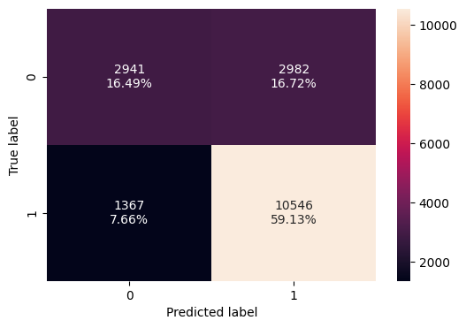

```python
## Creating confusion matrix for train data on tuned estimator
confusion_matrix_sklearn(gbc_tuned, X_train, Y_train)
```

```python
## Checking performance for train data on tuned estimator
gbc_tuned_model_train_perf = model_performance_classification_sklearn(gbc_tuned, X_train, Y_train)
gbc_tuned_model_train_perf
```

|  | Accuracy | Recall | Precision | F1 |
| --- | --- | --- | --- | --- |
| 0 | 0.756167 | 0.885251 | 0.779568 | 0.829055 |

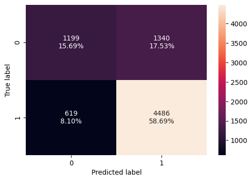

```python
## Creating confusion matrix for test data on tuned estimator
confusion_matrix_sklearn(gbc_tuned, X_test, Y_test)
```

```python
## Checking performance for test data on tuned estimator
gbc_tuned_model_test_perf = model_performance_classification_sklearn(gbc_tuned, X_test, Y_test)
gbc_tuned_model_test_perf
```

|  | Accuracy | Recall | Precision | F1 |
| --- | --- | --- | --- | --- |
| 0 | 0.743721 | 0.878746 | 0.769997 | 0.820785 |

- The F1 score is approximately same as in initial GB model, As The F1 score values are approximately same on both test and train data in tuned GB model, indicating model is well fitted on train and test data, F1 Scope indicates good model performance,

XGBoost Classifier

```python
## Building XGBoost Classifier with random state = 1 and eval_metric="logloss"
xgb_classifier = XGBClassifier(random_state=1, eval_metric="logloss")

## Fitting XGBoost Classifier on the train data
xgb_classifier.fit(X_train, Y_train)
```

```
XGBClassifier(base_score=None, booster=None, callbacks=None,
              colsample_bylevel=None, colsample_bynode=None,
              colsample_bytree=None, device=None, early_stopping_rounds=None,
              enable_categorical=False, eval_metric='logloss',
              feature_types=None, gamma=None, grow_policy=None,
              importance_type=None, interaction_constraints=None,
              learning_rate=None, max_bin=None, max_cat_threshold=None,
              max_cat_to_onehot=None, max_delta_step=None, max_depth=None,
              max_leaves=None, min_child_weight=None, missing=nan,
              monotone_constraints=None, multi_strategy=None, n_estimators=None,
              n_jobs=None, num_parallel_tree=None, random_state=1, ...)
```

Checking model performance on train and test data set

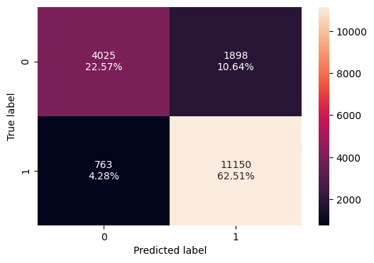

```python
## Creating confusion matrix for train data
confusion_matrix_sklearn(xgb_classifier, X_train, Y_train)
```

```python
## Checking performance on train data
xgb_classifier_model_train_perf = model_performance_classification_sklearn(xgb_classifier, X_train, Y_train)
xgb_classifier_model_train_perf
```

|  | Accuracy | Recall | Precision | F1 |
| --- | --- | --- | --- | --- |
| 0 | 0.850807 | 0.935952 | 0.854537 | 0.893394 |

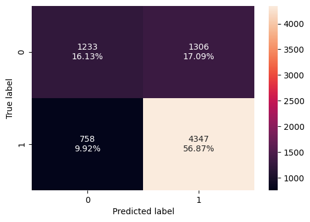

```python
## Creating confusion matrix for test data
confusion_matrix_sklearn(xgb_classifier, X_test, Y_test)
```

```python
## Checking performance for test data
xgb_classifier_model_test_perf = model_performance_classification_sklearn(xgb_classifier, X_test, Y_test)
xgb_classifier_model_test_perf
```

|  | Accuracy | Recall | Precision | F1 |
| --- | --- | --- | --- | --- |
| 0 | 0.729984 | 0.851518 | 0.768972 | 0.808143 |

- The F1 score of trian data is 0.89 and the F1 score of 0.80 on test data, the difference of around 0.09 between the training and test F1 scores is generally not alarming, but it does suggest that the model is not perfectly generalizing to unseen data.

Hyperparameter Tuning XGBoost Classifier

```python
# Choose the type of classifier.
xgb_tuned = XGBClassifier(random_state=1, eval_metric="logloss")

# Grid of parameters to choose from
parameters = {
    "n_estimators": np.arange(50,110,25),
    "scale_pos_weight": [1,2,5],
    "subsample": [0.9, 1],
    "learning_rate": [0.01,0.1,0.05],
    "gamma": [1,3]
}

# Type of scoring used to compare parameter combinations
acc_scorer = metrics.make_scorer(metrics.f1_score)

# Run the grid search with cv = 5
grid_obj = GridSearchCV(xgb_tuned, param_grid=parameters, scoring=acc_scorer, cv=5)

## Fitting the grid_obj on train data
grid_obj = grid_obj.fit(X_train, Y_train)

# Set the clf to the best combination of parameters
xgb_tuned = grid_obj.best_estimator_

# Fit the best algorithm to the data.
xgb_tuned.fit(X_train, Y_train)
```

```
XGBClassifier(base_score=None, booster=None, callbacks=None,
              colsample_bylevel=None, colsample_bynode=None,
              colsample_bytree=None, device=None, early_stopping_rounds=None,
              enable_categorical=False, eval_metric='logloss',
              feature_types=None, gamma=3, grow_policy=None,
              importance_type=None, interaction_constraints=None,
              learning_rate=0.05, max_bin=None, max_cat_threshold=None,
              max_cat_to_onehot=None, max_delta_step=None, max_depth=None,
              max_leaves=None, min_child_weight=None, missing=nan,
              monotone_constraints=None, multi_strategy=None, n_estimators=50,
              n_jobs=None, num_parallel_tree=None, random_state=1, ...)
```

Checking model performance on train and test data set

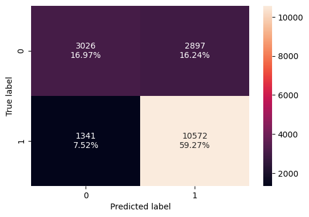

```python
## Creating confusion matrix for train data on tuned estimator
confusion_matrix_sklearn(xgb_tuned, X_train, Y_train)
```

```python
## Checking performance for train data on tuned estimator
xgb_tuned_model_train_perf = model_performance_classification_sklearn(xgb_tuned, X_train, Y_train)
xgb_tuned_model_train_perf
```

|  | Accuracy | Recall | Precision | F1 |
| --- | --- | --- | --- | --- |
| 0 | 0.762391 | 0.887434 | 0.784914 | 0.833031 |

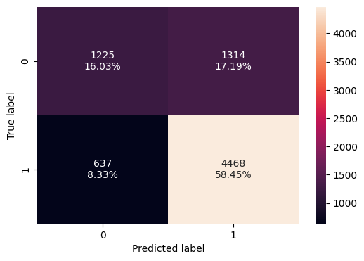

```python
## Creating confusion matrix for test data on tuned estimator
confusion_matrix_sklearn(xgb_tuned, X_test, Y_test)
```

```python
## Complete the code to check performance for test data on tuned estimator
xgb_tuned_model_test_perf = model_performance_classification_sklearn(xgb_tuned, X_test, Y_test)
xgb_tuned_model_test_perf
```

|  | Accuracy | Recall | Precision | F1 |
| --- | --- | --- | --- | --- |
| 0 | 0.744767 | 0.87522 | 0.772743 | 0.820795 |

- The F1 scores for both training and test data are quite close (0.833 on training vs. 0.821 on test). This is a positive outcome, as it suggests that the model is generalizing well and is not overfitting or underfitting.

Stacking Classifier

```python
estimators = [
    ("AdaBoost", ab_classifier),
    ("Gradient Boosting", gbc_tuned),
    ("Random Forest", rf_tuned),
]

final_estimator = xgb_tuned

## Defining Stacking Classifier
stacking_classifier = StackingClassifier(
    estimators=estimators, final_estimator=final_estimator, cv=5)

## Fitting Stacking Classifier on the train data
stacking_classifier.fit(X_train, Y_train)
```

```
StackingClassifier(cv=5,
                   estimators=[('AdaBoost', BaggingClassifier(random_state=1)),
                               ('Gradient Boosting',
                                GradientBoostingClassifier(init=AdaBoostClassifier(random_state=1),
                                                           max_features=0.9,
                                                           n_estimators=50,
                                                           random_state=1,
                                                           subsample=0.9)),
                               ('Random Forest',
                                RandomForestClassifier(class_weight='balanced',
                                                       max_depth=10,
                                                       min_samples_split=3,
                                                       n_estimators=30,
                                                       rand...
                                                 feature_types=None, gamma=3,
                                                 grow_policy=None,
                                                 importance_type=None,
                                                 interaction_constraints=None,
                                                 learning_rate=0.05,
                                                 max_bin=None,
                                                 max_cat_threshold=None,
                                                 max_cat_to_onehot=None,
                                                 max_delta_step=None,
                                                 max_depth=None,
                                                 max_leaves=None,
                                                 min_child_weight=None,
                                                 missing=nan,
                                                 monotone_constraints=None,
                                                 multi_strategy=None,
                                                 n_estimators=50, n_jobs=None,
                                                 num_parallel_tree=None,
                                                 random_state=1, ...))
```

Checking model performance on train and test data set

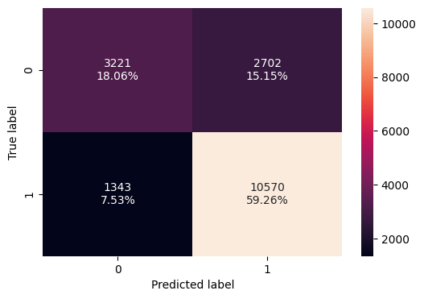

```python
## Creating confusion matrix for train data
confusion_matrix_sklearn(stacking_classifier, X_train, Y_train)
```

```python
 ## Checking performance on train data
stacking_classifier_model_train_perf = model_performance_classification_sklearn(stacking_classifier, X_train, Y_train)
stacking_classifier_model_train_perf
```

|  | Accuracy | Recall | Precision | F1 |
| --- | --- | --- | --- | --- |
| 0 | 0.773211 | 0.887266 | 0.796414 | 0.839389 |

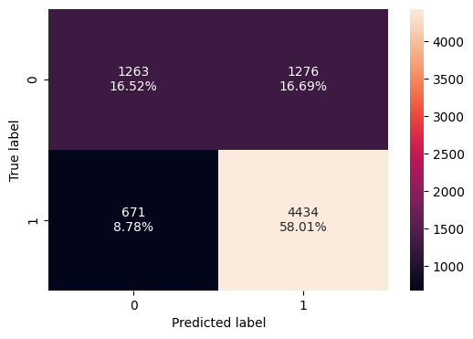

```python
## Creating confusion matrix for test data
confusion_matrix_sklearn(stacking_classifier, X_test, Y_test)
```

```python
## Checking performance for test data
stacking_classifier_model_test_perf = model_performance_classification_sklearn(stacking_classifier, X_test, Y_test)
stacking_classifier_model_test_perf
```

|  | Accuracy | Recall | Precision | F1 |
| --- | --- | --- | --- | --- |
| 0 | 0.74529 | 0.86856 | 0.776532 | 0.819972 |

- After Stacking the F1 scores for both training and test data are quite close (0.839 on training vs. 0.82 on test). it indicate that the model is generalizing well and is not overfitting or underfitting.
- Model Performance was slightly better on hypertuned XG boost model as compare to stacking.

## Model Performance Comparison and Conclusions

```python
# training performance comparison

models_train_comp_df = pd.concat(
    [
        decision_tree_perf_train.T,
        dtree_estimator_model_train_perf.T,
        bagging_classifier_model_train_perf.T,
        bagging_estimator_tuned_model_train_perf.T,
        rf_estimator_model_train_perf.T,
        rf_tuned_model_train_perf.T,
        ab_classifier_model_train_perf.T,
        abc_tuned_model_train_perf.T,
        gb_classifier_model_train_perf.T,
        gbc_tuned_model_train_perf.T,
        xgb_classifier_model_train_perf.T,
        xgb_tuned_model_train_perf.T,
        stacking_classifier_model_train_perf.T,
    ],
    axis=1,
)
models_train_comp_df.columns = [
    "Decision Tree",
    "Tuned Decision Tree",
    "Bagging Classifier",
    "Tuned Bagging Classifier",
    "Random Forest",
    "Tuned Random Forest",
    "Adaboost Classifier",
    "Tuned Adaboost Classifier",
    "Gradient Boost Classifier",
    "Tuned Gradient Boost Classifier",
    "XGBoost Classifier",
    "XGBoost Classifier Tuned",
    "Stacking Classifier",
]
print("Training performance comparison:")
models_train_comp_df
```

```
Training performance comparison:
```

|  | Decision Tree | Tuned Decision Tree | Bagging Classifier | Tuned Bagging Classifier | Random Forest | Tuned Random Forest | Adaboost Classifier | Tuned Adaboost Classifier | Gradient Boost Classifier | Tuned Gradient Boost Classifier | XGBoost Classifier | XGBoost Classifier Tuned | Stacking Classifier |
| --- | --- | --- | --- | --- | --- | --- | --- | --- | --- | --- | --- | --- | --- |
| Accuracy | 1.0 | 0.712548 | 0.985198 | 0.996187 | 1.0 | 0.765755 | 0.985198 | 0.754429 | 0.758802 | 0.756167 | 0.850807 | 0.762391 | 0.773211 |
| Recall | 1.0 | 0.931923 | 0.985982 | 0.999916 | 1.0 | 0.796105 | 0.985982 | 0.883908 | 0.883740 | 0.885251 | 0.935952 | 0.887434 | 0.887266 |
| Precision | 1.0 | 0.720067 | 0.991810 | 0.994407 | 1.0 | 0.844298 | 0.991810 | 0.778443 | 0.783042 | 0.779568 | 0.854537 | 0.784914 | 0.796414 |
| F1 | 1.0 | 0.812411 | 0.988887 | 0.997154 | 1.0 | 0.819494 | 0.988887 | 0.827830 | 0.830349 | 0.829055 | 0.893394 | 0.833031 | 0.839389 |

```python
# testing performance comparison
models_test_comp_df = pd.concat(
    [
        decision_tree_perf_test.T,
        dtree_estimator_model_test_perf.T,
        bagging_classifier_model_test_perf.T,
        bagging_estimator_tuned_model_test_perf.T,
        rf_estimator_model_test_perf.T,
        rf_tuned_model_test_perf.T,
        ab_classifier_model_test_perf.T,
        abc_tuned_model_test_perf.T,
        gb_classifier_model_test_perf.T,
        gbc_tuned_model_test_perf.T,
        xgb_classifier_model_test_perf.T,
        xgb_tuned_model_test_perf.T,
        stacking_classifier_model_test_perf.T,
    ],
    axis=1,)

models_test_comp_df.columns = [
    "Decision Tree",
    "Tuned Decision Tree",
    "Bagging Classifier",
    "Tuned Bagging Classifier",
    "Random Forest",
    "Tuned Random Forest",
    "Adaboost Classifier",
    "Tuned Adaboost Classifier",
    "Gradient Boost Classifier",
    "Tuned Gradient Boost Classifier",
    "XGBoost Classifier",
    "XGBoost Classifier Tuned",
    "Stacking Classifier",
]
print("Training performance comparison:")
models_test_comp_df
```

[output not shown]

|  | Decision Tree | Tuned Decision Tree | Bagging Classifier | Tuned Bagging Classifier | Random Forest | Tuned Random Forest | Adaboost Classifier | Tuned Adaboost Classifier | Gradient Boost Classifier | Tuned Gradient Boost Classifier | XGBoost Classifier | XGBoost Classifier Tuned | Stacking Classifier |
| --- | --- | --- | --- | --- | --- | --- | --- | --- | --- | --- | --- | --- | --- |
| Accuracy | 0.654893 | 0.706567 | 0.691523 | 0.724228 | 0.727368 | 0.718995 | 0.691523 | 0.741104 | 0.744767 | 0.743721 | 0.729984 | 0.744767 | 0.745290 |
| Recall | 0.747502 | 0.930852 | 0.764153 | 0.895397 | 0.847209 | 0.763565 | 0.764153 | 0.876004 | 0.876004 | 0.878746 | 0.851518 | 0.875220 | 0.868560 |
| Precision | 0.738819 | 0.715447 | 0.771711 | 0.743857 | 0.768343 | 0.805538 | 0.771711 | 0.768649 | 0.772366 | 0.769997 | 0.768972 | 0.772743 | 0.776532 |
| F1 | 0.743135 | 0.809058 | 0.767913 | 0.812622 | 0.805851 | 0.783990 | 0.767913 | 0.818823 | 0.820927 | 0.820785 | 0.808143 | 0.820795 | 0.819972 |

- As per comparision the Tuned XGBoost Calssifier Model and Tuned Gradient boosting models have the best performace as it is quite well gernalise on train-test data as compare to other models. F1 Score for both models on train test data set is approximately same with balanced recall and precision, however we have to select 1 as final model, so will go with Tuned XGBoost Calssifier.
- The F1 score is the harmonic mean of precision and recall, so an F1 score of training set 0.83 and test set 0.82 for tuned XG boost model, which suggests that the model is managing to strike a good balance between precision (correctly predicting positive instances) and recall (capturing all positive instances).
- The >82 F1 scores on both training and testing, it indicates that the model is likely capturing the key patterns in the data while avoiding memorization of irrelevant noise.
- This also suggests that the model has achieved good generalization, meaning it's likely to perform well on new, unseen data, which is our ultimate goal.

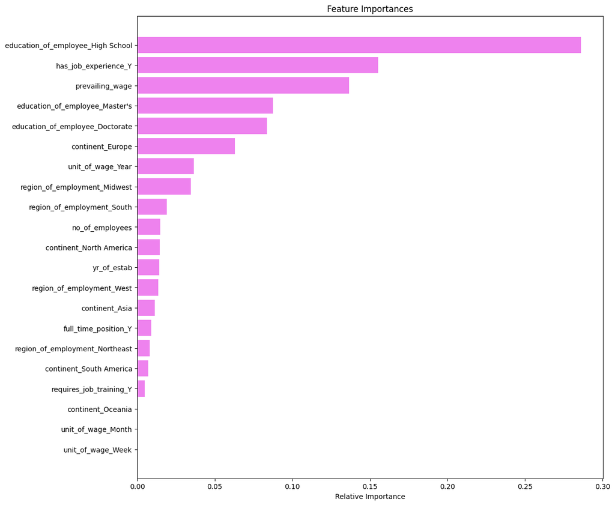

```python
feature_names = X_train.columns
importances = gb_classifier.feature_importances_
indices = np.argsort(importances)

plt.figure(figsize=(12, 12))
plt.title("Feature Importances")
plt.barh(range(len(indices)), importances[indices], color="violet", align="center")
plt.yticks(range(len(indices)), [feature_names[i] for i in indices])
plt.xlabel("Relative Importance")
plt.show()
```

- Education of employees with highschool is the most important feature followed by Job experirnce and prevailing wages, these 3 are the top contributers to the models.
- Education of employees with masters and doctorates are approximately equally important, overall education of employees is an quite important feature in model predictions,
- Rest of features lower in importance but do contribute to model performance, but Oceania, Unit of wages in week and month not showing any contribution in model

## Actionable Insights and Recommendations

Model Feature Insights

Recommendations

- The goal of improving the visa approval process is to ensure that it is both fair and efficient while preventing non-deserving candidates from receiving visas. By tightening requirements, ensuring wage compliance, using data verification systems, and focusing on the actual needs of the labor market.
- As the Eduaction is most improtant feature in prediction, the agency should Clearly define the required education level for visa categories (e.g., Bachelor's, Master's, or Doctoral degree). This helps ensure that applicants meet the necessary qualifications for the positions they are applying for and it will help the agency for easy application filtration for deserved candidates.
- The agency should ensure that the applicant's education and experience align with the job they are being offered or applying for, For example, if a person with a Bachelor's degree in Computer Science is applying for a highly skilled tech job, their role should align with the level of education and expertise they possess.
- The agency should try to categorize employment roles based on their skill levels (e.g., low, medium, and high skill). This will ensures that visas are granted based on the candidate’s skill level, and low-skill jobs are not given to foreign workers when they could be filled by local candidates.
- For high-skill jobs, prioritize full-time employment over part-time. Full-time positions should be given preference for visa approval to ensure that foreign workers are sufficiently integrated into the labor market and contribute effectively to the economy.
- For part-time positions, ensure that the visa applicant’s employment status justifies the need for a foreign worker. For instance, part-time roles may be more appropriate for jobs in sectors where there is a clear labor shortage, or if the applicant has unique expertise.
- In Conclusion the agency to use advanced algorithms to spot inconsistencies in application forms, such as mismatched education levels or unrealistic salary expectations for certain job roles. Automated checks can flag applications for human review if any red flags are identified.